# Анализ факторов оттока клиентов фитнес-центра

### Промежуточный вывод

- Серьезной разницы в метриках между моделями не наблюдается.
- Модели с порогом оказались хуже обычных.
- Самый важный фактор - средняя частота тренировок.
- Также важны такие факторы, как длительность купленного абонемента, время пользования услугами и тд., но это скорее очевидные характеристики лояльных клиентов, нежели факторы, которые влияют на их удержание.
- Помимо прочего важны возраст клиента, промоакции, проживание вблизи от фитнес-центра.

Вернуться к оглавлению

## Кластеризация клиентов

### Стандартизация данных

```python
sc = StandardScaler()
x_sc = sc.fit_transform(gym)
```

Вернуться к оглавлению

### Иерархическая кластеризация, оценка оптимального числа кластеров

```python
linked = linkage(x_sc, method = 'ward')
```

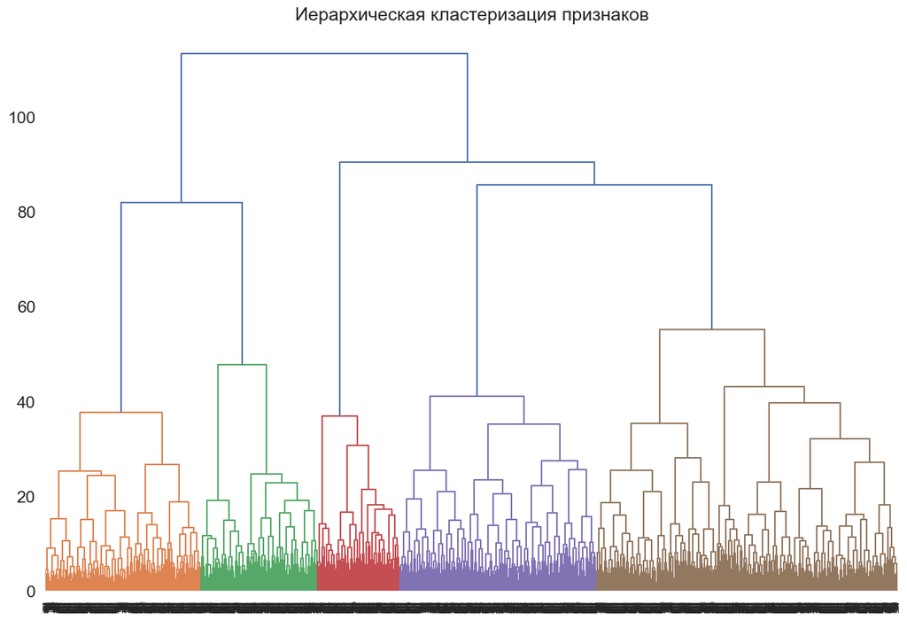

```python
plt.figure(figsize=(15, 10))
dendrogram(linked, orientation='top')
plt.title('Иерархическая кластеризация признаков')
plt.show()
```

Итак, иерархическая кластеризация подсказывает нам, что оптимальное число кластеров - 5, что в принципе совпадает с ТЗ, теперь осталось сгруппировать пользователей с помощью K-means.

Вернуться к оглавлению

### Кластеризация методом K-means

```python
km = KMeans(n_clusters=5, random_state=0)
```

```python
labels = km.fit_predict(x_sc)
```

```python
gym['cluster_km'] = labels
```

Вернуться к оглавлению